# Quality controls of RNAseq data

Project: Tridentomic ; PI: Mourad Bekhouche

# Project

The aim of the project is to check that data produced by the chosen technique are suitable for the analyses of the entire cohort.  
We present here the results of extensive quality controls of the data.

# Data

The following table summarizes the details of the sequenced samples.

| SampleID | Gender | Time |
| --- | --- | --- |
| 1_Fille15_10-03_J0 | Fille | J0 |
| 10_Garcon15_14-03_J0 | Garcon | J0 |
| 11_Garcon15_14-03_J2 | Garcon | J2 |
| 12_Garcon15_14-03_J4 | Garcon | J4 |
| 13_Garcon16_14-03_J0 | Garcon | J0 |
| 14_Garcon16_14-03_J2 | Garcon | J2 |
| 15_Garcon16_14-03_J4 | Garcon | J4 |
| 16_Garcon17_28-02_J0 | Garcon | J0 |
| 17_Garcon17_28-02_J2 | Garcon | J2 |
| 18_Garcon17_28-02_J4 | Garcon | J4 |

[output cut: 10 more lines]

# Methods

RNA extractions were sequenced on the CLB platform, on an Illumina Novaseq machine with a paired-end protocol.

Libraries were prepared with the mRNA PolyA kit.

Raw sequencing reads were aligned on the human genome (GRCh38) with STAR (v2.7.8a), with the annotation of known genes from gencode v37.

Gene expression was quantified using Salmon (1.4.0) and the annotation of protein coding genes from gencode v37.

# Quality controls

## Raw sequences quality controls

We control here the quality of the raw data before transcriptome reconstruction.  
As the samples were sequenced with a paired-end protocol, we have 2 files for each samples: one with forward reads and one with the reverse ones. As long as the transcriptome is not reconstructed, we treat all the files separately.

### Sequence count

This graph shows the number of sequenced reads for each sample, colored by its uniqueness.  
Duplicated reads are common in transcriptomic data, as they reflect the expression of a gene. They usually represent between 40 and 60% of the sequenced reads.

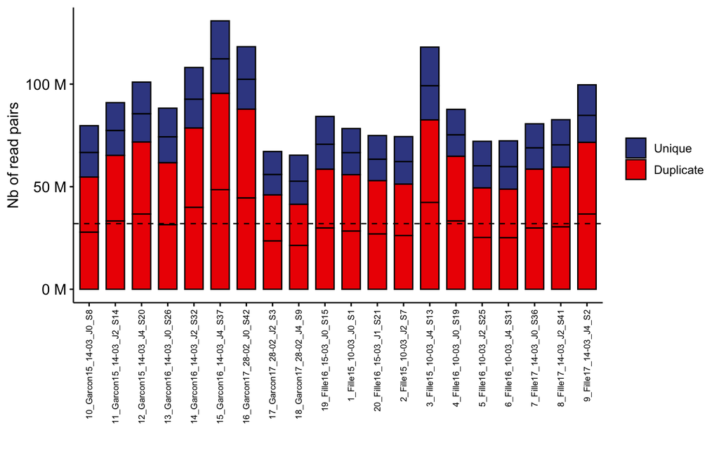

### GC content

We continue with the GC content of the sequenced reads.  
Here the GC content of each read is computed, and the profile of the entire sample is compared to a reference one. If it is too divergent, curves are colored in orange for warning, and red it is completely different.

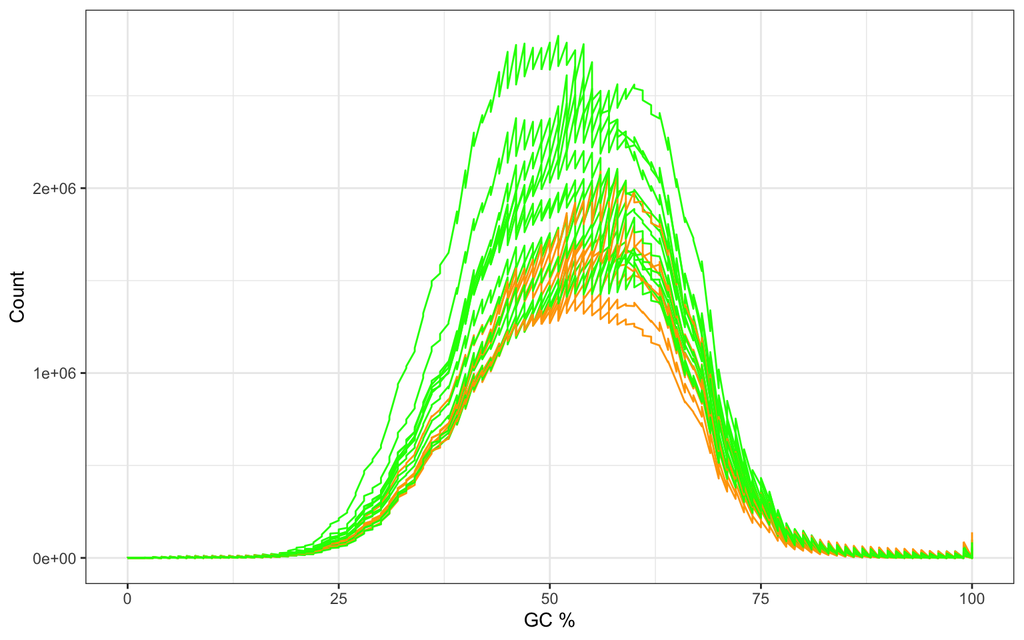

Almost all samples have distribution of GC followwing the theoretical curve.

### Base content

Let’s have a look at the base content of the reads.  
The following graph represents the proportion of each of the 4 bases along the read, for all the reads of a sample.  
We show here the example of one sample, 1_Fille15_10-03_J0.

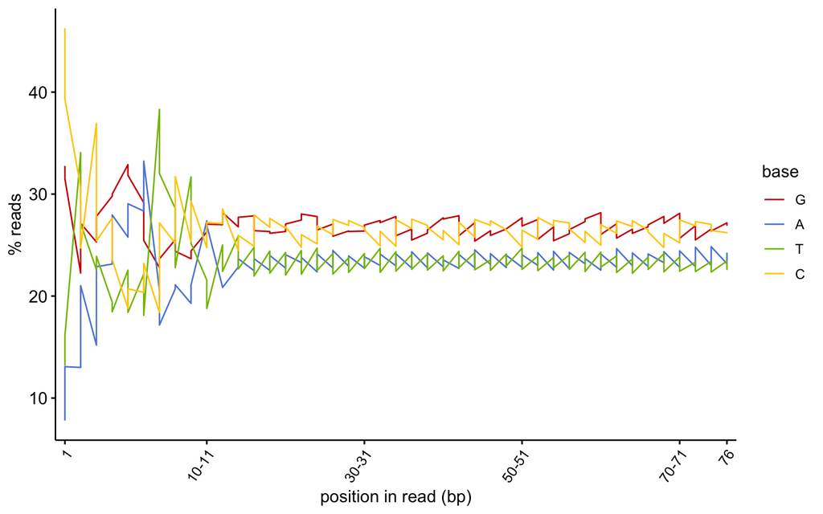

if we ignore the variations at the beginning of the reads that are common for illumina, we can see that the bases are almost balanced. We checked all the samples and they have similar curves.

### Mapping statistics

To continue the quality controls, we align all the samples on the human transcriptome and check their molecular content.  
The proportion of mapped reads is a good indicator of a sample quality (we really sequenced human transcriptome and not something else for example).  
The graph below shows the proportion of mapped reads for all the samples.

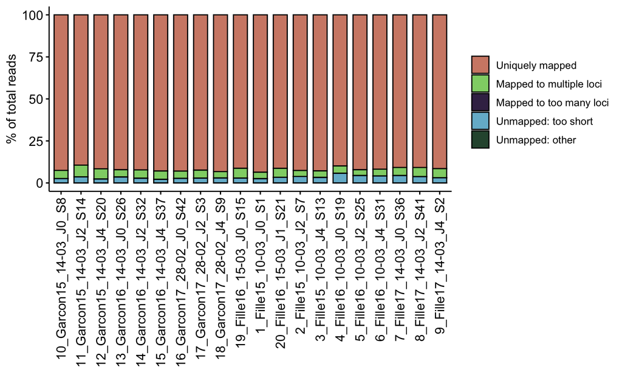

The results are good, with around 90% of the reads aligned uniquely (reads aligning to multiple loci are difficult to interpret, as they can be PCR duplicates or low quality sequences that we cannot reconstruct exactly).

### Fragment size

Once the reads are aligned on the transcriptome, we can guess the size of the original fragment that was sequenced (in the case of paired end data, each reads correspond to an extremity of the fragment, forward and reverse).  
Fragment size is controlled during the sequencing experiment, which means that the majority of fragment should have roughly the same size.  
An abundance of smaller or longer fragments can indicate a problem during the sequencing.  
Also if the fragments are smaller than the reads size, the latter will overlap and we loose the interest of paired end sequencing.  
The following graphs represents the distribution of fragments size for all the samples.

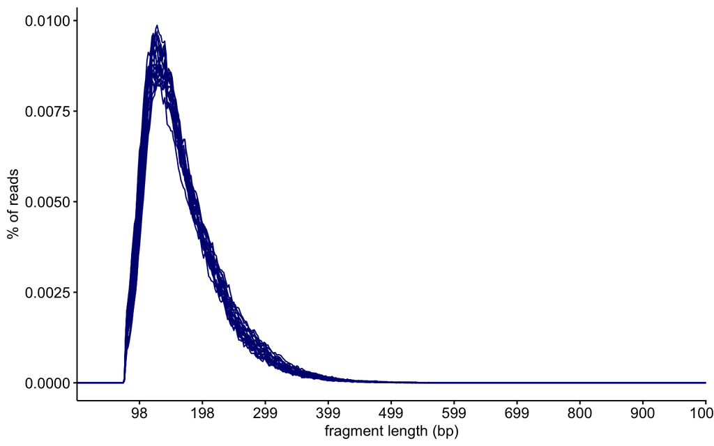

The mean fragment size is around 126 bp for all the samples.

### Library content

If we look only at the mapped reads, we can see where they aligned on the transcriptome and reconstruct the library content.  
On this graph we colored the reads by the part of the transcripts they probably come from.  
As we plan to study the gene expression, we would like to have a proportion of exons as high as possible.

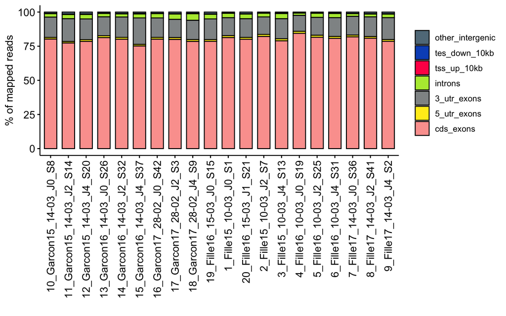

Aroud 80% of the reads are exonic, which is good and confirms that we effectively captured mRNA and that the majority of the data will be usable.

### rRNA

For the last part of our raw sequenced quality controls we look at the ribosomal RNAs.  
Library preparation kits are supposed to deplete them, otherwise they represent the majority of the transcripts in a cell.  
We align the reads on the rRNA sequences to check if the depletion worked.  
We consider a sample usable if we find less than 25% of reads on the rRNAs.

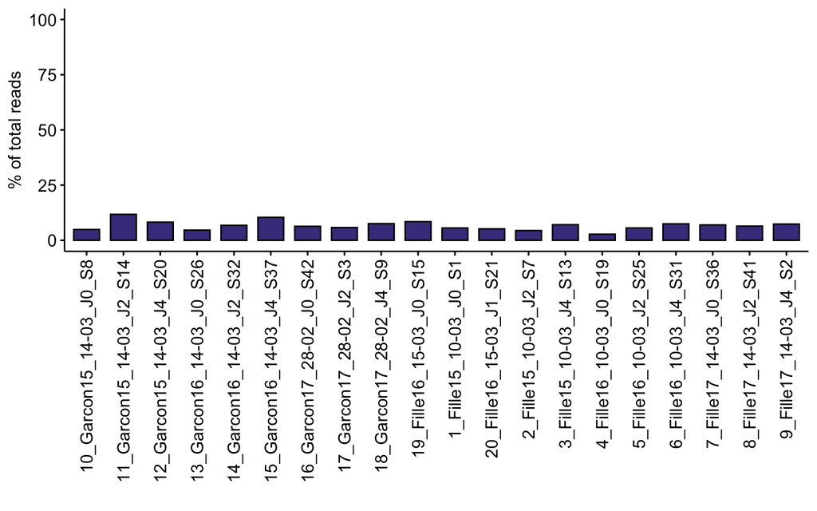

This is ok, all samples are below the 25% limit.

### TIN

TIN, transcript integrity number, is a value (from 0 to 100) to evaluate the sequenced transcripts integrity, as a reflect of RIN (RNA integrity number). The most degraded RNA, the lowest the tin number.  
We represent here the median TIN for all transcripts of each sample.

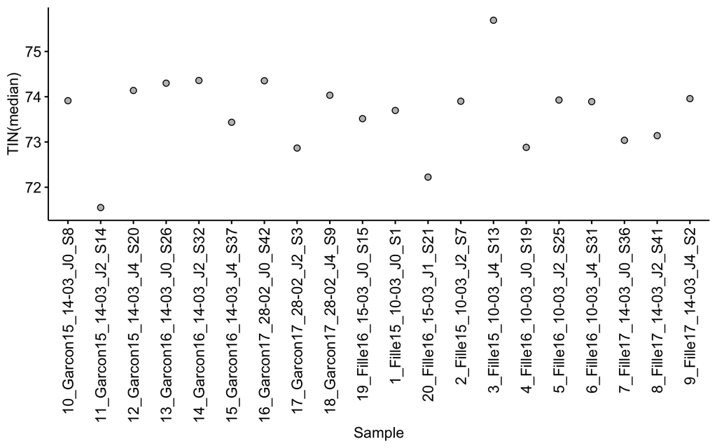

The values are around 73%, which is really good and reflect we have sequenced high quality samples.

## Gene expression quality controls

Now that the raw data quality controls are over we transform the aligned reads into gene expression and continue with the controls.  
The aim is to check that the expression data is coherent with the biological samples and suitable for statistical analyses.

### Data distribution

In the graph below, each row corresponds to the distribution of the raw counts per gene for a given sample, without the “zeros”, i. e. the genes not expressed in this sample:

- the median is represented by the grey line in the centre
- the grey vertical bar corresponds to the interquartile (0.25-0.75).
- the grey moustache at the top is the quantile 0.95.
- the blue vertical bar goes from the mean to the mean plus 1 standard deviation (without the values at zeroes).
- the blue moustache (down) corresponds to the average with the zeros.
- Finally, the percentage of “zeros” in each distribution is indicated by the grey point in the center (right y axis).

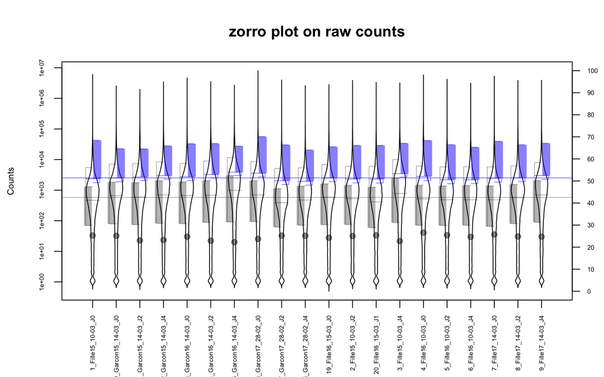

Data here are reduced to protein coding genes.

We can see that the raw expression data distributions are similar for all the samples

We found less than 30% of genes with 0 counts for each sample. This leads us to believe that we sequenced enough genes to reach a normal distribution.

We can check this by looking at the number of genes with sufficient counts for analysis (here we choose 10)

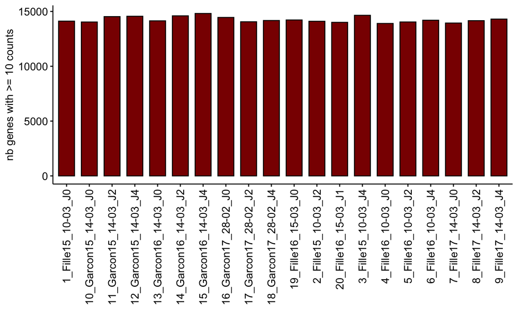

All the samples have around 14000 detected genes.

This confirms that all the samples were sequenced enough to reach the distributions we usually work with.

### Correspondance analysis

Like the PCA, the COA is a statistical method used to project data on plans or axes, in order to visualize and study the shape of the “data cloud”. The specificity of the COA is that it considers at the same time the variables and the individuals. It will group the individuals according to a pattern of values .  
We want to see how the samples are naturally grouped and where the main variance of the dataset lies.

To be perfect, replicates for each group should be together on the graph.

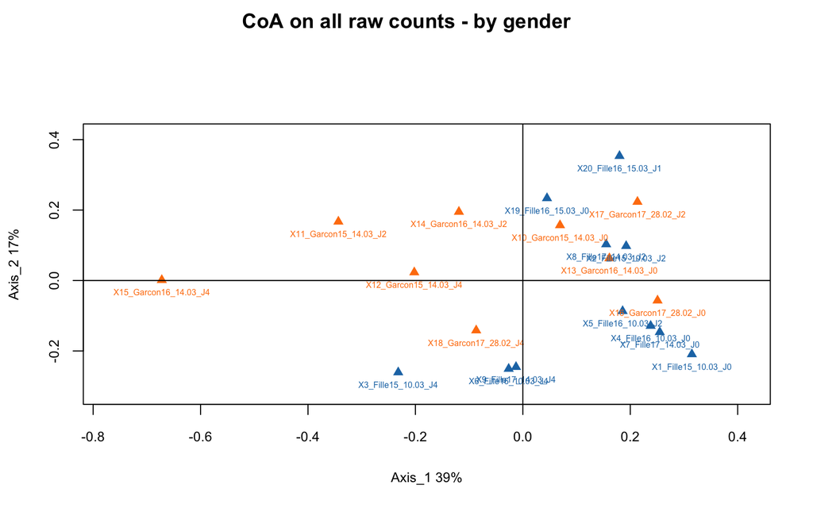

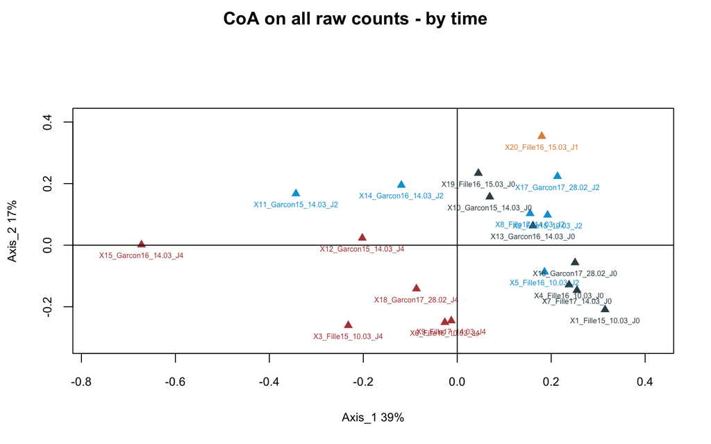

Difficult to conclude on this without more information about the samples.

# Conclusion

Careful quality controls showed us that the samples are of rather good quality.  
It seems we have a signal we should be able to explore gene expression in further analyses.

# Session info

|  | version |
| --- | --- |
| System | x86_64, darwin17.0 |
| R | R version 4.1.0 (2021-05-18) |
| ade4 | 1.7-17 |
| annotables | 0.1.91 |
| beanplot | 1.2 |
| dplyr | 1.0.7 |
| DT | 0.19 |
| fastqcr | 0.1.2 |
| ggeasy | 0.1.3 |
| ggplot2 | 3.3.5 |
| ggpubr | 0.4.0 |
| ggsci | 2.9 |
| hrbrthemes | 0.8.0 |
| jsonlite | 1.7.2 |
| kableExtra | 1.3.4 |
| knitr | 1.33 |
| patchwork | 1.1.1 |
| RColorBrewer | 1.1-2 |
| readr | 2.0.1 |
| reshape2 | 1.4.4 |
| scales | 1.1.1 |
| tibble | 3.1.4 |